# Exam_3_Porter

Chris Porter

12/5/2019

## Data Exploration

| Column ID | Description |
| --- | --- |
| **Sample.ID** | The location the sample was taken from. There are 2 water samples and 2 soil samples. |
| **Rep** | The experimental replicate. 3 replicates for each combination of experimental variables. |
| **Well** | The well number on the BioLog plate. |
| **Dilution** | The dilution factor of the sample. |
| **Substrate** | The name of the carbon source in that well. “Water” is the negative control. |
| **ElapsedTime** | Number of hours of incubation at which absorbance reading was taken. |
| **Absorbance** | The light absorbance value. |

In order to better characterize the data, the data set was examined to determine areas of potential interest.

```r
summary(df)
```

```
##        Sample.ID        Rep         Well         Dilution
##  Clear_Creek:864   Min.   :1   A1     : 108   Min.   :0.001
##  Waste_Water:864   1st Qu.:1   A2     : 108   1st Qu.:0.001
##  Soil_1     :864   Median :2   A3     : 108   Median :0.010
##  Soil_2     :864   Mean   :2   A4     : 108   Mean   :0.037
##                    3rd Qu.:3   B1     : 108   3rd Qu.:0.100
##                    Max.   :3   B2     : 108   Max.   :0.100
##                                (Other):2808
##                         Substrate    ElapsedTime   Absorbance
##  2-Hydroxy Benzoic Acid      : 108   24 :1152    Min.   :0.0000
##  4-Hydroxy Benzoic Acid      : 108   48 :1152    1st Qu.:0.0050
##  D-Cellobiose                : 108   144:1152    Median :0.1860
##  D-Galactonic Acid Î³-Lactone: 108               Mean   :0.5215
##  D-Galacturonic Acid         : 108               3rd Qu.:0.8110
##  D-Glucosaminic Acid         : 108               Max.   :3.1160
##  (Other)                     :2808
```

### Exploration Plots

#### Verification of Controls

Of interest was to determine if any of the control samples showed evidence of contamination

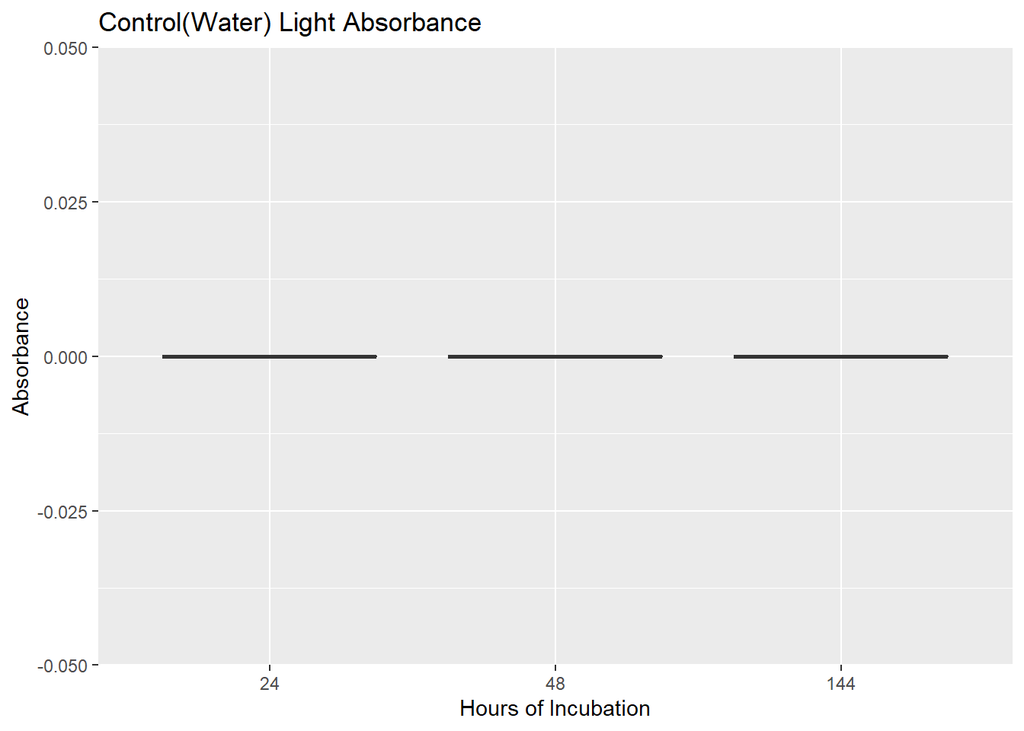

It can be observed that none of the control wells displayed evidence of contamination.

#### Absorbance by Sample Type

Next, we explored the data to determine if there were any correlations that might be of interest.

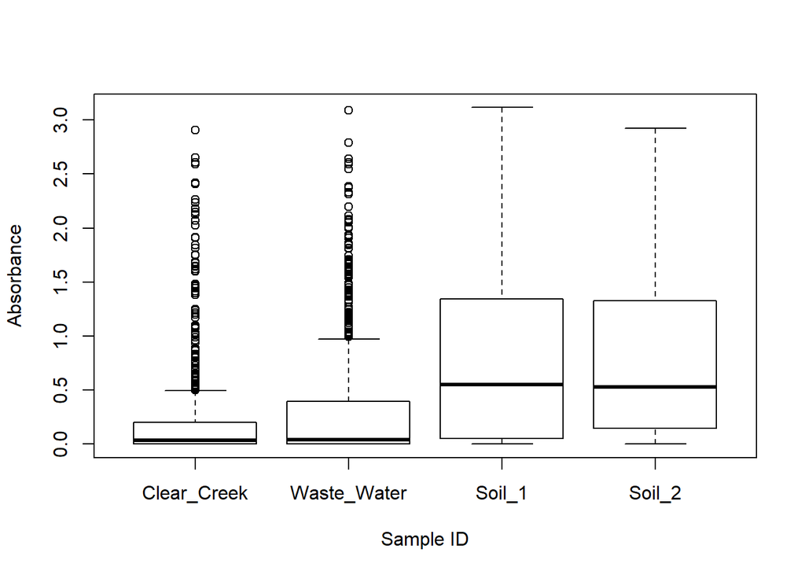

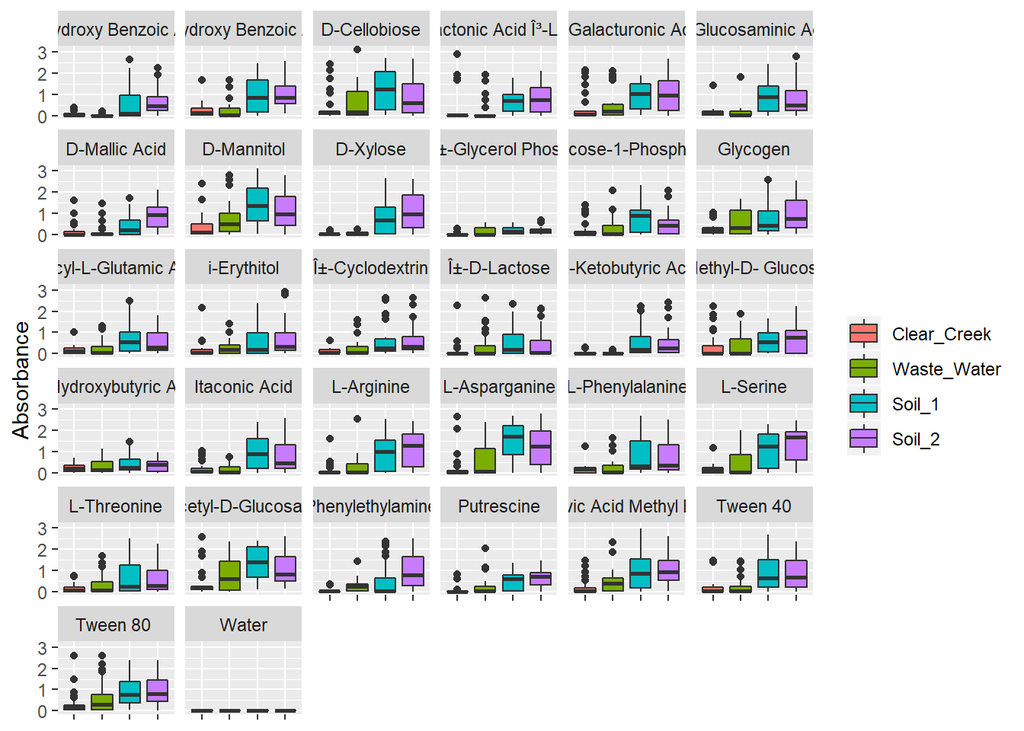

Examining these charts, we see that the soil samples generally trend towards a greater about of substrate utilization than water samples. We can see in the second chart that some substrates display a marked difference between samples from water sources, and samples from soil sources. Other substrates seem to be evenly distributed across all sample types.

The data above includes all dilution levels and so we examined the effect of Dilution on Absorbance

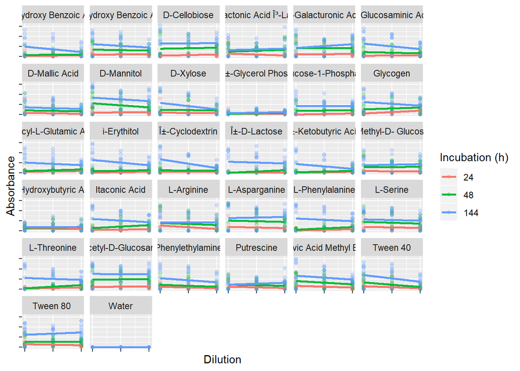

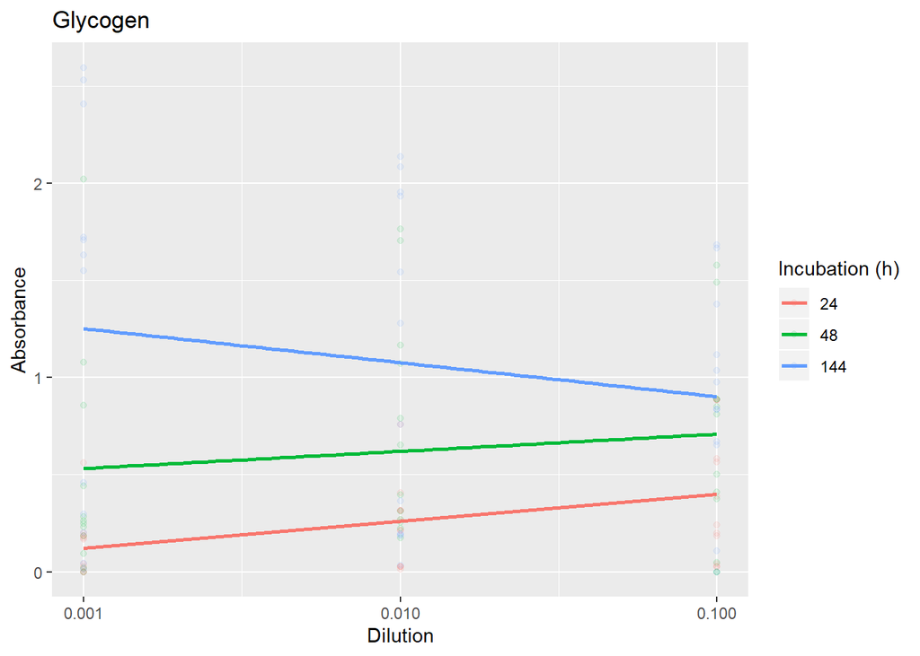

There are several C-substrates that demonstrate a unique profile exemplified by that of Glycogen, above. At higher concentrations, there is a higher intitial metabolic activity at 24h, but eventually a lower overall metabolic activity at 144h. Whereas at lower concentrations, the intial metabolism is lower, but continues on to end up with a higher overall level of metabolism. Indeed, there are many metabolites which display a greater level of metabolism at lower concentrations than at higher ones, particularly at 144h.

## Soil vs Water Microbial Metabolism

As was seen above, there is a significant difference between samples from water sources and samples from soil samples in their ability to metabolize C-substrates.

```
## # A tibble: 32 x 4
##    Substrate                     Soil  Water Difference
##    <fct>                        <dbl>  <dbl>      <dbl>
##  1 L-Asparganine                1.51  0.023       1.48
##  2 L-Serine                     1.39  0.118       1.28
##  3 L-Arginine                   1.15  0.0085      1.14
##  4 D-Mannitol                   1.19  0.270       0.916
##  5 D-Galacturonic Acid          1.02  0.13        0.885
##  6 N-Acetyl-D-Glucosamine       1.08  0.262       0.813
##  7 Pyruvic Acid Methyl Ester    0.889 0.089       0.800
##  8 4-Hydroxy Benzoic Acid       0.844 0.0905      0.754
##  9 D-Cellobiose                 0.878 0.139       0.738
## 10 D-Galactonic Acid Î³-Lactone 0.725 0.002       0.723
## # ... with 22 more rows
```

We examined which metabolites are driving this difference in metabolic activity. The above table gives the 10 most important contributors to this discrepency.

## Conclusion

We have shown that there is a significant difference in the metabolic activity of microbiomes located in water environments as opposed to those found in soil environments. We were able to show that this is a general trend, but also were able to identify the most important metabolites that contribute to this observed difference. We also identified that the dilution of the sample can sometimes display a counter-intuitive increase in metabolic activity. It was also shown that the control showed no evidence of contamination.